# Risk Factor Analysis

## Outcome Variable

**Outcome Variable:** stunted

## Predictor Variables

**Intervention Variable:** safeh20

**Adjustment Set:**

unadjusted

## Stratifying Variables

The analysis was stratified on these variable(s):

- agecat
- studyid
- country

## Data Summary

| agecat | studyid | country | safeh20 | stunted | n_cell | n |
| --- | --- | --- | --- | --- | --- | --- |
| Birth | ki0047075b-MAL-ED | BANGLADESH | 0 | 0 | 196 | 234 |
| Birth | ki0047075b-MAL-ED | BANGLADESH | 0 | 1 | 38 | 234 |
| 6 months | ki0047075b-MAL-ED | BANGLADESH | 0 | 0 | 195 | 240 |
| 6 months | ki0047075b-MAL-ED | BANGLADESH | 0 | 1 | 45 | 240 |
| 24 months | ki0047075b-MAL-ED | BANGLADESH | 0 | 0 | 114 | 212 |
| 24 months | ki0047075b-MAL-ED | BANGLADESH | 0 | 1 | 98 | 212 |
| Birth | ki0047075b-MAL-ED | BRAZIL | 0 | 0 | 113 | 124 |
| Birth | ki0047075b-MAL-ED | BRAZIL | 0 | 1 | 11 | 124 |
| 6 months | ki0047075b-MAL-ED | BRAZIL | 0 | 0 | 140 | 142 |
| 6 months | ki0047075b-MAL-ED | BRAZIL | 0 | 1 | 2 | 142 |
| 24 months | ki0047075b-MAL-ED | BRAZIL | 0 | 0 | 110 | 113 |
| 24 months | ki0047075b-MAL-ED | BRAZIL | 0 | 1 | 3 | 113 |
| Birth | ki0047075b-MAL-ED | INDIA | 0 | 0 | 161 | 191 |
| Birth | ki0047075b-MAL-ED | INDIA | 0 | 1 | 30 | 191 |
| 6 months | ki0047075b-MAL-ED | INDIA | 0 | 0 | 190 | 235 |
| 6 months | ki0047075b-MAL-ED | INDIA | 0 | 1 | 45 | 235 |
| 24 months | ki0047075b-MAL-ED | INDIA | 0 | 0 | 132 | 227 |
| 24 months | ki0047075b-MAL-ED | INDIA | 0 | 1 | 95 | 227 |
| 6 months | ki0047075b-MAL-ED | NEPAL | 0 | 0 | 221 | 233 |
| 6 months | ki0047075b-MAL-ED | NEPAL | 0 | 1 | 11 | 233 |
| 6 months | ki0047075b-MAL-ED | NEPAL | 1 | 0 | 1 | 233 |
| 6 months | ki0047075b-MAL-ED | NEPAL | 1 | 1 | 0 | 233 |
| 24 months | ki0047075b-MAL-ED | NEPAL | 0 | 0 | 176 | 226 |
| 24 months | ki0047075b-MAL-ED | NEPAL | 0 | 1 | 49 | 226 |
| 24 months | ki0047075b-MAL-ED | NEPAL | 1 | 0 | 1 | 226 |
| 24 months | ki0047075b-MAL-ED | NEPAL | 1 | 1 | 0 | 226 |
| Birth | ki0047075b-MAL-ED | NEPAL | 0 | 0 | 150 | 168 |
| Birth | ki0047075b-MAL-ED | NEPAL | 0 | 1 | 17 | 168 |
| Birth | ki0047075b-MAL-ED | NEPAL | 1 | 0 | 1 | 168 |
| Birth | ki0047075b-MAL-ED | NEPAL | 1 | 1 | 0 | 168 |

[output cut: 96 more lines]

The following strata were considered:

- agecat: 24 months, studyid: ki0047075b-MAL-ED, country: BANGLADESH
- agecat: 24 months, studyid: ki0047075b-MAL-ED, country: BRAZIL
- agecat: 24 months, studyid: ki0047075b-MAL-ED, country: INDIA
- agecat: 24 months, studyid: ki0047075b-MAL-ED, country: NEPAL
- agecat: 24 months, studyid: ki0047075b-MAL-ED, country: PERU
- agecat: 24 months, studyid: ki0047075b-MAL-ED, country: SOUTH AFRICA
- agecat: 24 months, studyid: ki0047075b-MAL-ED, country: TANZANIA, UNITED REPUBLIC OF
- agecat: 24 months, studyid: ki1017093-NIH-Birth, country: BANGLADESH
- agecat: 24 months, studyid: ki1017093b-PROVIDE, country: BANGLADESH
- agecat: 24 months, studyid: ki1017093c-NIH-Crypto, country: BANGLADESH
- agecat: 24 months, studyid: ki1114097-CONTENT, country: PERU
- agecat: 24 months, studyid: ki1148112-LCNI-5, country: MALAWI
- agecat: 24 months, studyid: kiGH5241-JiVitA-3, country: BANGLADESH
- agecat: 24 months, studyid: kiGH5241-JiVitA-4, country: BANGLADESH
- agecat: 6 months, studyid: ki0047075b-MAL-ED, country: BANGLADESH
- agecat: 6 months, studyid: ki0047075b-MAL-ED, country: BRAZIL
- agecat: 6 months, studyid: ki0047075b-MAL-ED, country: INDIA
- agecat: 6 months, studyid: ki0047075b-MAL-ED, country: NEPAL
- agecat: 6 months, studyid: ki0047075b-MAL-ED, country: PERU
- agecat: 6 months, studyid: ki0047075b-MAL-ED, country: SOUTH AFRICA
- agecat: 6 months, studyid: ki0047075b-MAL-ED, country: TANZANIA, UNITED REPUBLIC OF
- agecat: 6 months, studyid: ki1000304b-SAS-FoodSuppl, country: INDIA
- agecat: 6 months, studyid: ki1017093-NIH-Birth, country: BANGLADESH
- agecat: 6 months, studyid: ki1017093b-PROVIDE, country: BANGLADESH
- agecat: 6 months, studyid: ki1017093c-NIH-Crypto, country: BANGLADESH
- agecat: 6 months, studyid: ki1114097-CONTENT, country: PERU
- agecat: 6 months, studyid: ki1148112-LCNI-5, country: MALAWI
- agecat: 6 months, studyid: kiGH5241-JiVitA-3, country: BANGLADESH
- agecat: 6 months, studyid: kiGH5241-JiVitA-4, country: BANGLADESH
- agecat: Birth, studyid: ki0047075b-MAL-ED, country: BANGLADESH
- agecat: Birth, studyid: ki0047075b-MAL-ED, country: BRAZIL
- agecat: Birth, studyid: ki0047075b-MAL-ED, country: INDIA
- agecat: Birth, studyid: ki0047075b-MAL-ED, country: NEPAL
- agecat: Birth, studyid: ki0047075b-MAL-ED, country: PERU
- agecat: Birth, studyid: ki0047075b-MAL-ED, country: SOUTH AFRICA
- agecat: Birth, studyid: ki0047075b-MAL-ED, country: TANZANIA, UNITED REPUBLIC OF
- agecat: Birth, studyid: ki1017093-NIH-Birth, country: BANGLADESH
- agecat: Birth, studyid: ki1017093c-NIH-Crypto, country: BANGLADESH
- agecat: Birth, studyid: kiGH5241-JiVitA-3, country: BANGLADESH
- agecat: Birth, studyid: kiGH5241-JiVitA-4, country: BANGLADESH

### Dropped Strata

Some strata were dropped due to rare outcomes:

- agecat: 6 months, studyid: ki0047075b-MAL-ED, country: BRAZIL
- agecat: 24 months, studyid: ki0047075b-MAL-ED, country: BRAZIL
- agecat: 6 months, studyid: ki0047075b-MAL-ED, country: NEPAL
- agecat: 24 months, studyid: ki0047075b-MAL-ED, country: NEPAL
- agecat: Birth, studyid: ki0047075b-MAL-ED, country: NEPAL
- agecat: Birth, studyid: ki0047075b-MAL-ED, country: PERU
- agecat: 6 months, studyid: ki0047075b-MAL-ED, country: PERU
- agecat: 24 months, studyid: ki0047075b-MAL-ED, country: PERU
- agecat: Birth, studyid: ki0047075b-MAL-ED, country: SOUTH AFRICA
- agecat: 6 months, studyid: ki1017093-NIH-Birth, country: BANGLADESH
- agecat: 24 months, studyid: ki1017093-NIH-Birth, country: BANGLADESH
- agecat: Birth, studyid: ki1017093-NIH-Birth, country: BANGLADESH
- agecat: 6 months, studyid: ki1114097-CONTENT, country: PERU
- agecat: 24 months, studyid: ki1114097-CONTENT, country: PERU
- agecat: 24 months, studyid: kiGH5241-JiVitA-3, country: BANGLADESH
- agecat: 24 months, studyid: kiGH5241-JiVitA-4, country: BANGLADESH
- agecat: 6 months, studyid: kiGH5241-JiVitA-4, country: BANGLADESH

## Methods Detail

We’re interested in the causal parameters $E[Y_a]$ for all values of $a \in \mathcal{A}$. These parameters represent the mean outcome if, possibly contrary to fact, we intervened to set all units to have $A=a$. Under the randomization and positivity assumptions, these are identified by the statistical parameters $\psi_a=E_W[E_{Y|A,W}(Y|A=a,W)]$. In addition, we’re interested in the mean of $Y$, $E[Y]$ under no intervention (the observed mean). We will estimate these parameters by using SuperLearner to fit the relevant likelihood factors – $E_{Y|A,W}(Y|A=a,W)$ and $p(A=a|W)$, and then updating our likelihood fit using a joint TMLE.

For unadjusted analyses ($W=\{\}$), initial likelihoods were estimated using Lrnr_glm to estimate the simple $E(Y|A)$ and Lrnr_mean to estimate $p(A)$. For adjusted analyses, a small library containing Lrnr_glmnet, Lrnr_xgboost, and Lrnr_mean was used.

Having estimated these parameters, we will then use the delta method to estimate relative risks and attributable risks relative to a prespecified baseline level of $A$.

```
##        stunted
## safeh20   0   1
##       0 114  98
##       1   0   0
##        stunted
## safeh20   0   1
##       0 132  95
##       1   0   0
##        stunted
## safeh20   0   1
##       0   0   0
##       1 386 190
##        stunted
## safeh20   0   1
##       0   0   0
##       1 382 132
##        stunted
## safeh20   0   1
##       0 195  45
##       1   0   0
##        stunted
## safeh20   0   1
##       0 190  45
##       1   0   0
##        stunted
## safeh20   0   1
##       0   0   0
##       1 217 163
##        stunted
## safeh20   0   1
##       0   0   0
##       1 487  94
##        stunted
## safeh20   0   1
##       0   0   0
##       1 565 150
##        stunted
## safeh20   0   1
##       0 196  38
##       1   0   0
##        stunted
## safeh20   0   1
##       0 113  11
##       1   0   0
##        stunted
## safeh20   0   1
##       0 161  30
##       1   0   0
##        stunted
## safeh20  0  1
##       0  0  0
##       1 22  5
##        stunted
## safeh20   0   1
##       0   0   0
##       1 575 247
```

# Results Detail

## Results Plots

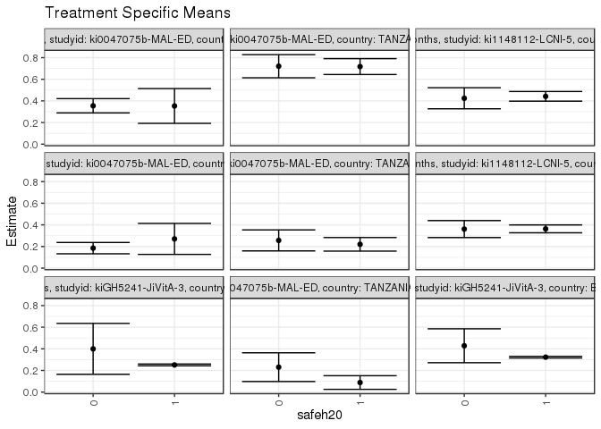

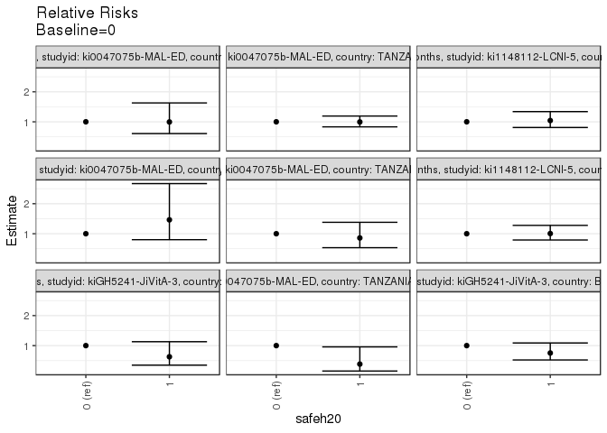

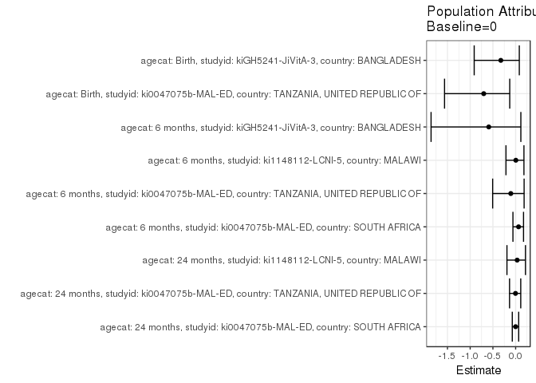

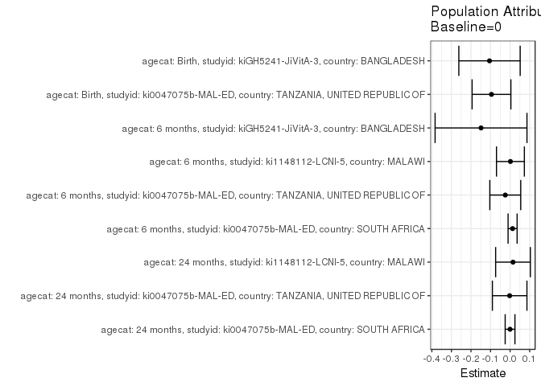

## Results Table

### Parameter: TSM

| agecat | studyid | country | intervention_level | baseline_level | estimate | ci_lower | ci_upper |
| --- | --- | --- | --- | --- | --- | --- | --- |
| Birth | ki0047075b-MAL-ED | TANZANIA, UNITED REPUBLIC OF | 0 | NA | 0.2307692 | 0.0979744 | 0.3635641 |
| Birth | ki0047075b-MAL-ED | TANZANIA, UNITED REPUBLIC OF | 1 | NA | 0.0886076 | 0.0256757 | 0.1515395 |
| Birth | kiGH5241-JiVitA-3 | BANGLADESH | 0 | NA | 0.4285714 | 0.2718731 | 0.5852697 |
| Birth | kiGH5241-JiVitA-3 | BANGLADESH | 1 | NA | 0.3230903 | 0.3154198 | 0.3307608 |
| 6 months | ki0047075b-MAL-ED | SOUTH AFRICA | 0 | NA | 0.1848341 | 0.1323536 | 0.2373147 |
| 6 months | ki0047075b-MAL-ED | SOUTH AFRICA | 1 | NA | 0.2702703 | 0.1268849 | 0.4136556 |
| 6 months | ki0047075b-MAL-ED | TANZANIA, UNITED REPUBLIC OF | 0 | NA | 0.2564103 | 0.1593102 | 0.3535104 |
| 6 months | ki0047075b-MAL-ED | TANZANIA, UNITED REPUBLIC OF | 1 | NA | 0.2202381 | 0.1574460 | 0.2830302 |
| 6 months | ki1148112-LCNI-5 | MALAWI | 0 | NA | 0.3611111 | 0.2826117 | 0.4396105 |
| 6 months | ki1148112-LCNI-5 | MALAWI | 1 | NA | 0.3630952 | 0.3267140 | 0.3994765 |
| 6 months | kiGH5241-JiVitA-3 | BANGLADESH | 0 | NA | 0.4000000 | 0.1645728 | 0.6354272 |
| 6 months | kiGH5241-JiVitA-3 | BANGLADESH | 1 | NA | 0.2512066 | 0.2430920 | 0.2593212 |
| 24 months | ki0047075b-MAL-ED | SOUTH AFRICA | 0 | NA | 0.3546798 | 0.2887284 | 0.4206312 |
| 24 months | ki0047075b-MAL-ED | SOUTH AFRICA | 1 | NA | 0.3529412 | 0.1919694 | 0.5139130 |
| 24 months | ki0047075b-MAL-ED | TANZANIA, UNITED REPUBLIC OF | 0 | NA | 0.7205882 | 0.6136873 | 0.8274892 |
| 24 months | ki0047075b-MAL-ED | TANZANIA, UNITED REPUBLIC OF | 1 | NA | 0.7172414 | 0.6437686 | 0.7907142 |
| 24 months | ki1148112-LCNI-5 | MALAWI | 0 | NA | 0.4242424 | 0.3268027 | 0.5216821 |
| 24 months | ki1148112-LCNI-5 | MALAWI | 1 | NA | 0.4421053 | 0.3974041 | 0.4868064 |

### Parameter: E(Y)

| agecat | studyid | country | intervention_level | baseline_level | estimate | ci_lower | ci_upper |
| --- | --- | --- | --- | --- | --- | --- | --- |
| Birth | ki0047075b-MAL-ED | TANZANIA, UNITED REPUBLIC OF | NA | NA | 0.1355932 | 0.0735587 | 0.1976277 |
| Birth | kiGH5241-JiVitA-3 | BANGLADESH | NA | NA | 0.3232787 | 0.3156210 | 0.3309364 |
| 6 months | ki0047075b-MAL-ED | SOUTH AFRICA | NA | NA | 0.1975806 | 0.1479246 | 0.2472367 |
| 6 months | ki0047075b-MAL-ED | TANZANIA, UNITED REPUBLIC OF | NA | NA | 0.2317073 | 0.1788752 | 0.2845395 |
| 6 months | ki1148112-LCNI-5 | MALAWI | NA | NA | 0.3627451 | 0.3297365 | 0.3957537 |
| 6 months | kiGH5241-JiVitA-3 | BANGLADESH | NA | NA | 0.2513837 | 0.2432545 | 0.2595129 |
| 24 months | ki0047075b-MAL-ED | SOUTH AFRICA | NA | NA | 0.3544304 | 0.2934024 | 0.4154584 |
| 24 months | ki0047075b-MAL-ED | TANZANIA, UNITED REPUBLIC OF | NA | NA | 0.7183099 | 0.6577588 | 0.7788609 |
| 24 months | ki1148112-LCNI-5 | MALAWI | NA | NA | 0.4390244 | 0.3983906 | 0.4796582 |

### Parameter: RR

| agecat | studyid | country | intervention_level | baseline_level | estimate | ci_lower | ci_upper |
| --- | --- | --- | --- | --- | --- | --- | --- |
| Birth | ki0047075b-MAL-ED | TANZANIA, UNITED REPUBLIC OF | 0 | 0 | 1.0000000 | 1.0000000 | 1.0000000 |
| Birth | ki0047075b-MAL-ED | TANZANIA, UNITED REPUBLIC OF | 1 | 0 | 0.3839662 | 0.1539245 | 0.9578076 |
| Birth | kiGH5241-JiVitA-3 | BANGLADESH | 0 | 0 | 1.0000000 | 1.0000000 | 1.0000000 |
| Birth | kiGH5241-JiVitA-3 | BANGLADESH | 1 | 0 | 0.7538774 | 0.5223317 | 1.0880654 |
| 6 months | ki0047075b-MAL-ED | SOUTH AFRICA | 0 | 0 | 1.0000000 | 1.0000000 | 1.0000000 |
| 6 months | ki0047075b-MAL-ED | SOUTH AFRICA | 1 | 0 | 1.4622315 | 0.8011048 | 2.6689653 |
| 6 months | ki0047075b-MAL-ED | TANZANIA, UNITED REPUBLIC OF | 0 | 0 | 1.0000000 | 1.0000000 | 1.0000000 |
| 6 months | ki0047075b-MAL-ED | TANZANIA, UNITED REPUBLIC OF | 1 | 0 | 0.8589286 | 0.5346790 | 1.3798154 |
| 6 months | ki1148112-LCNI-5 | MALAWI | 0 | 0 | 1.0000000 | 1.0000000 | 1.0000000 |
| 6 months | ki1148112-LCNI-5 | MALAWI | 1 | 0 | 1.0054945 | 0.7914536 | 1.2774206 |
| 6 months | kiGH5241-JiVitA-3 | BANGLADESH | 0 | 0 | 1.0000000 | 1.0000000 | 1.0000000 |
| 6 months | kiGH5241-JiVitA-3 | BANGLADESH | 1 | 0 | 0.6280164 | 0.3489781 | 1.1301701 |
| 24 months | ki0047075b-MAL-ED | SOUTH AFRICA | 0 | 0 | 1.0000000 | 1.0000000 | 1.0000000 |
| 24 months | ki0047075b-MAL-ED | SOUTH AFRICA | 1 | 0 | 0.9950980 | 0.6080796 | 1.6284384 |
| 24 months | ki0047075b-MAL-ED | TANZANIA, UNITED REPUBLIC OF | 0 | 0 | 1.0000000 | 1.0000000 | 1.0000000 |
| 24 months | ki0047075b-MAL-ED | TANZANIA, UNITED REPUBLIC OF | 1 | 0 | 0.9953554 | 0.8311555 | 1.1919940 |
| 24 months | ki1148112-LCNI-5 | MALAWI | 0 | 0 | 1.0000000 | 1.0000000 | 1.0000000 |
| 24 months | ki1148112-LCNI-5 | MALAWI | 1 | 0 | 1.0421053 | 0.8108219 | 1.3393611 |

### Parameter: PAR

| agecat | studyid | country | intervention_level | baseline_level | estimate | ci_lower | ci_upper |
| --- | --- | --- | --- | --- | --- | --- | --- |
| Birth | ki0047075b-MAL-ED | TANZANIA, UNITED REPUBLIC OF | 0 | NA | -0.0951760 | -0.1943025 | 0.0039505 |
| Birth | kiGH5241-JiVitA-3 | BANGLADESH | 0 | NA | -0.1052927 | -0.2620587 | 0.0514733 |
| 6 months | ki0047075b-MAL-ED | SOUTH AFRICA | 0 | NA | 0.0127465 | -0.0103476 | 0.0358407 |
| 6 months | ki0047075b-MAL-ED | TANZANIA, UNITED REPUBLIC OF | 0 | NA | -0.0247029 | -0.1037008 | 0.0542949 |
| 6 months | ki1148112-LCNI-5 | MALAWI | 0 | NA | 0.0016340 | -0.0696180 | 0.0728859 |
| 6 months | kiGH5241-JiVitA-3 | BANGLADESH | 0 | NA | -0.1486163 | -0.3834328 | 0.0862002 |
| 24 months | ki0047075b-MAL-ED | SOUTH AFRICA | 0 | NA | -0.0002494 | -0.0252056 | 0.0247068 |
| 24 months | ki0047075b-MAL-ED | TANZANIA, UNITED REPUBLIC OF | 0 | NA | -0.0022784 | -0.0905825 | 0.0860257 |
| 24 months | ki1148112-LCNI-5 | MALAWI | 0 | NA | 0.0147820 | -0.0739338 | 0.1034978 |

### Parameter: PAF

| agecat | studyid | country | intervention_level | baseline_level | estimate | ci_lower | ci_upper |
| --- | --- | --- | --- | --- | --- | --- | --- |
| Birth | ki0047075b-MAL-ED | TANZANIA, UNITED REPUBLIC OF | 0 | NA | -0.7019231 | -1.5639195 | -0.1297321 |
| Birth | kiGH5241-JiVitA-3 | BANGLADESH | 0 | NA | -0.3257026 | -0.9116555 | 0.0806464 |
| 6 months | ki0047075b-MAL-ED | SOUTH AFRICA | 0 | NA | 0.0645130 | -0.0592989 | 0.1738537 |
| 6 months | ki0047075b-MAL-ED | TANZANIA, UNITED REPUBLIC OF | 0 | NA | -0.1066127 | -0.5055147 | 0.1865960 |
| 6 months | ki1148112-LCNI-5 | MALAWI | 0 | NA | 0.0045045 | -0.2126384 | 0.1827644 |
| 6 months | kiGH5241-JiVitA-3 | BANGLADESH | 0 | NA | -0.5911932 | -1.8603739 | 0.1148375 |
| 24 months | ki0047075b-MAL-ED | SOUTH AFRICA | 0 | NA | -0.0007037 | -0.0736521 | 0.0672883 |
| 24 months | ki0047075b-MAL-ED | TANZANIA, UNITED REPUBLIC OF | 0 | NA | -0.0031719 | -0.1339561 | 0.1125284 |
| 24 months | ki1148112-LCNI-5 | MALAWI | 0 | NA | 0.0336700 | -0.1911017 | 0.2160253 |